# Eksploracyjna analizę danych o Irysach

## 1.Badamy poszczególne kolumny

### 1.1 Sprawdźmy ile jest poszczególnych irysów osiągających daną wartości miary poszczególnych elementów ich budowy

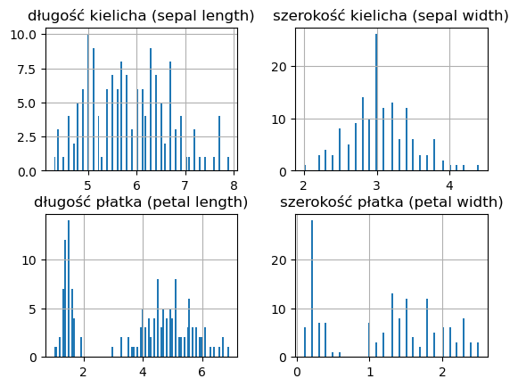

### 1.2 Pogrupujemy teraz irysy na wszytskie dostępne gatunki i sprawdźmy poszczególne średie,mediany,min i max wartości elementów ich budowy

#### 1.2.1 Wykresy średnich i median rozmiarów elementów budowy dla poszczególnych gatunów

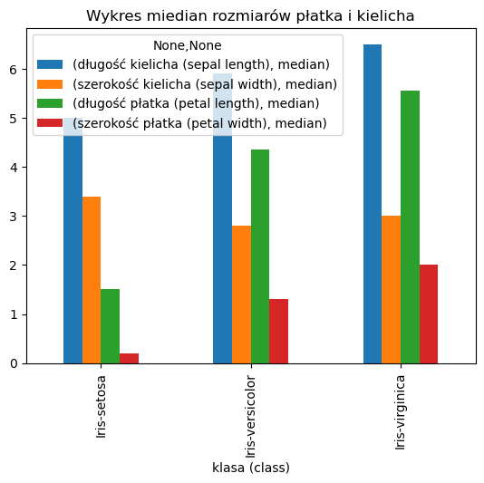

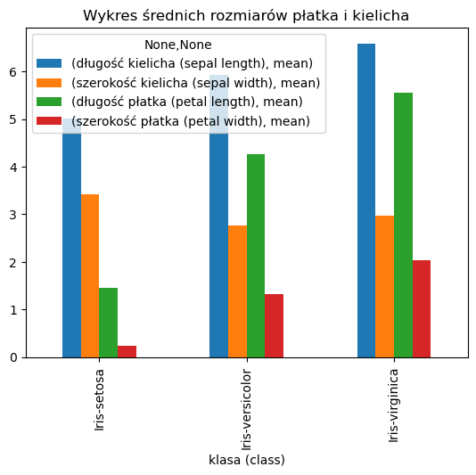

Możemy zaobserwować, że:

- **Największą średnią długość** kielicha osągają Iris-virginica i , że mediana wartości długośc kielicha jest u każdego gatunku zbliżona do średniej, czyli spodziewmy się, **że jest mało** irysów o znacząco mniejszej, czy większej długości kielcha
- **Największą średnią** szerokość kielicha osągają Iris-setosa i , że mediana wartości szerokości kielicha jest u każdego gatunku zbliżona do średniej, czyli spodziewmy się, że jest mało irysów o znacząco mniejszej, czy większej długości kielcha
- Za to **znacznie najmniejszą średnią** długość płatka osągają Iris-setosa i , że mediana wartości długości płatka jest u każdego gatunku zbliżona do średniej, czyli spodziewmy się, że jest mało irysów o znacząco **mniejszej, czy większej** długości kielcha

#### 1.2.2 Wykrs słupkowy wartości min i max dla poszczególych gatunków

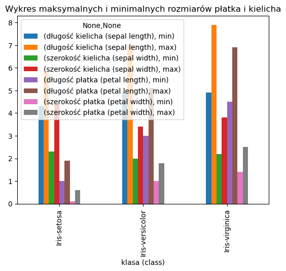

Powyższy wykres ukazuje coś co już zaobserwowaliśmy przy okazji wykrsu słupkowego ze średnią wartości elementów budowy kwiata, a mianowicie widzimy, że Iris-setosa ma **zancznie mniejsze minimalne** rozmiary płatków niż to wystpuje u inych gatunków

### 1.3 Następnie przestdiujemy histogramy wszystkich wartośc dla poszczególnych gatunków

#### 1.3.1 Histogram budowy kwiatu dla Iris-setosa

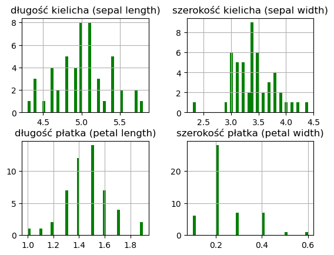

#### 1.3.2 Histogramy budowy kwiatu dla Iris-versicolor

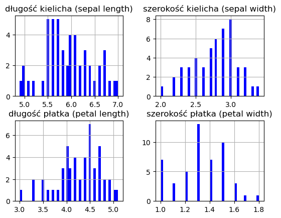

#### 1.3.3 Histogramy budowy kwiatu dla Iris-virginica

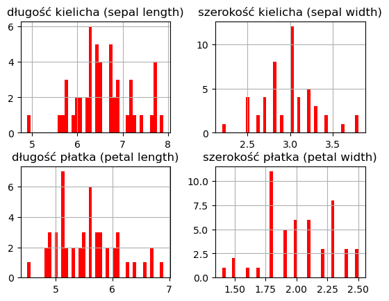

Porównjąc histogramy obserwujemy, że:

## 2. Szukanie korelacji w danych

#### 2.1 Sprawdzamy korelacje międzyposzczegónymi elmentami budowy Iris-setosa

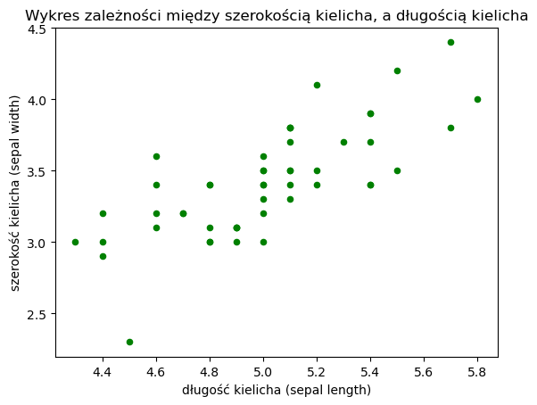

Obserwujemy dużą korelację u gatunku Iris-setosa w długości kielicha do szrokości kielicha, to znaczy, że **im większe** są długości kielicha, to obserwujemy więcej kwiaów tego gatunku o **większych** rozmiarach szerokości kielicha

#### 2.2 Sprawdzamy korelacje międzyposzczegónymi elementami budowy Iris-versicolor

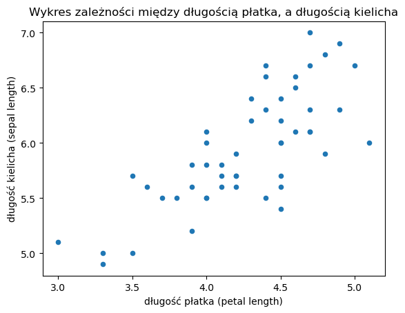

Obserwujemy dużą korelację u gatunku Iris-versicolor w długości płatka do długości kielicha, to znaczy, że **im większe** są długości płatków, to obserwujemy więcej kwiaów tego gatunku **o większych** rozmiarach długości kielicha

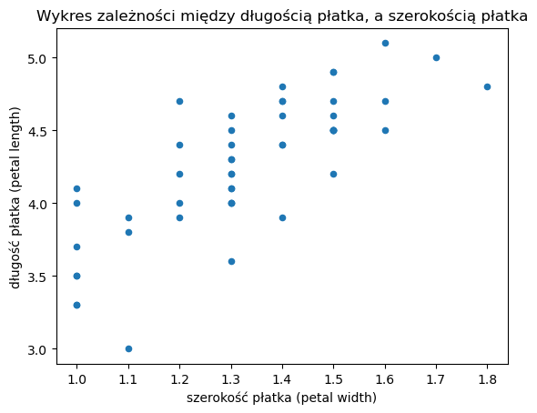

Obserwujemy dużą korelację u gatunku Iris-versicolor w długości płatka do szerokości płatków kielicha, to znaczy, że **im większe** są długości płatków, to obserwujemy więcej kwiaów tego gatunku **o większych** rozmiarach szerokości płatków

#### 2.3 Sprawdzamy korelacje międzyposzczegónymi elementami budowy Iris-virginica

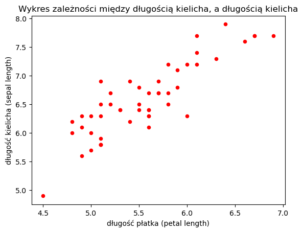

Obserwujemy **bardzo dużą** korelację u gatunku Iris-virginica w długości kielicha do długości płatka, to znaczy, **że im większe** są długości kielicha, to obserwujemy **więcej kwiatów** tego gatunku o większych rozmiarach długości płatka

## 3. Szukanie watości odstających

### 3.1 Wykres pudłkowy Iris-setosa

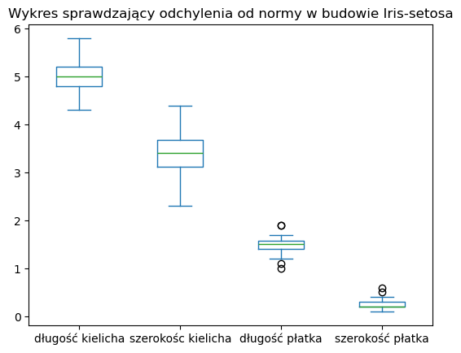

Widzimy, że u gatunku Iris-setosa wystpują kwiaty, które mają długości i szerokości płatka **odstające od normy** badanych kwiatów tego gatunku

### 3.2 Wykres pudłkowy Iris-versicolor

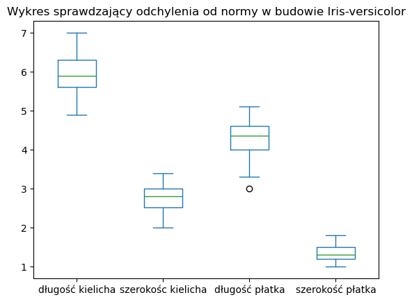

Widzimy, że u gatunku Iris-versicolor wystpują kwiaty, które mają długości płatka **odstające od normy** badanych kwiatów tego gatunku

### 3.3 Wykres pudłkowy Iris-virginica

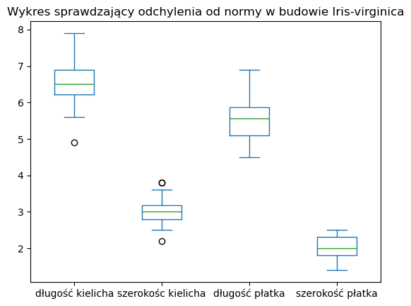

Widzimy, że u gatunku Iris-virginica wystpuje kwiat lub kwiaty, które mają długości kielicha odstające bardzo od normy badanych kwiatów tego gatunku. Można zaobserwować również kwiaty o rozmiarach szerokości kielicha **mnniejszych lub większych** od normy w tym gatunku

## 4. Podsumowanie

### 4.2 Podsumowanie analizy korealcji

- U gatunku Iris-setosa **im większe** są długości kielicha, to obserwujemy więcej kwiaów tego gatunku o **większych** rozmiarach szerokości kielicha
- U gatunku Iris-versicolor **im większe** są długości płatków, to obserwujemy więcej kwiaów tego gatunku **o większych** rozmiarach długości kielicha
- U kwiatów Iris-versicolor zaobserwowalismy, że **im większe** są długości płatków, to obserwujemy więcej kwiaów tego gatunku **o większych** rozmiarach szerokości płatków
- U gatunku Iris-virginica **im większe** są długości kielicha, to obserwujemy **więcej kwiatów** tego gatunku o większych rozmiarach długości płatka